# A Prototype of Gaussian Process(GP/GRF) based Interactive Species Distribution Models with Biological Prior Knowledge

Chathura Gunasekara

Dec 29, 2016

This prototype compares performace of predicting species destributions with the established MaxEnt method and the GRaF package based Gaussing process model.Using limited presense data of a reptile species (Xantusia Riversiana) a predictive model is created and performance is evaluated.

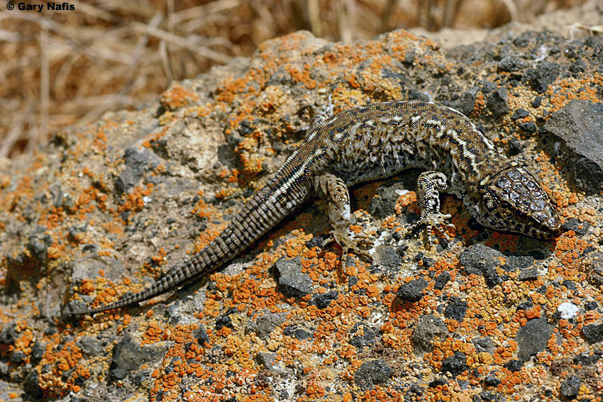

The first step in any species distribution model is to plot the presence locations on a map.

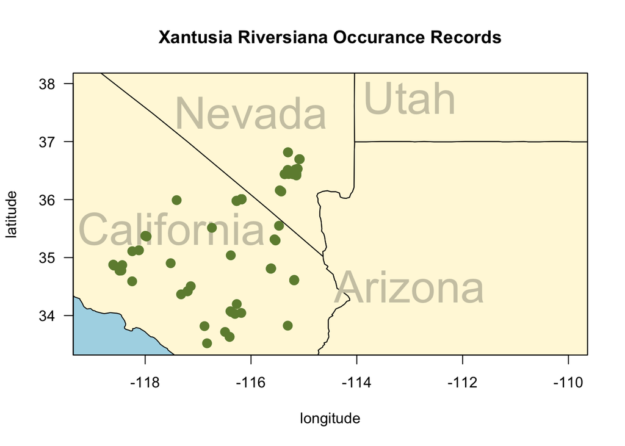

```r
# load package and data
library(maptools)
library(maps)
library(mapdata)
library(dismo)
library(GRaF)
library(pROC)
locs = read.csv(file="./Xantusia_riversiana.csv", header=T, sep=",")
locs <-locs[1:100,]
colnames(locs)<-c("ind","species","lat","lon")
plot(c(-119, -110), c(33.5, 38), mar=par("mar"), xlab="longitude", ylab="latitude", xaxt="n", yaxt="n", type="n", main="Xantusia Riversiana Occurance Records")
rect(par("usr")[1],par("usr")[3],par("usr")[2],par("usr")[4], col="lightblue")
map("state", xlim=c(-119, -110), ylim=c(33.5, 38), fill=T, col="cornsilk", add=T)

text(x=-117.5, y=35.5, "California", col="cornsilk3", cex=3)
text(x=-116, y=37.5, "Nevada", col="cornsilk3", cex=3)
text(x=-113, y=34.5, "Arizona", col="cornsilk3", cex=3)
text(x=-113, y=37.75, "Utah", col="cornsilk3", cex=3)

points(locs$lon, locs$lat, col="darkolivegreen4", pch=20, cex=2)

axis(1,las=1)
axis(2,las=1)
box()
```

The map shows the samples are distributed in mostly suthern parts of california.

The formal pre-processing step before further analysis when conducting species destribution models is correcting for sampling bias.

```r
# create sequences of latitude and longitude values to define the grid
longrid = seq(-119, -110,0.05)
latgrid = seq(33.5, 38,0.05)

# identify points within each grid cell, draw one at random
subs = c()
for(i in 1:(length(longrid)-1)){
  for(j in 1:(length(latgrid)-1)){
    gridsq = subset(locs, lat > latgrid[j] & lat < latgrid[j+1] & lon > longrid[i] & lon < longrid[i+1])
    if(dim(gridsq)[1]>0){
      subs = rbind(subs, gridsq[sample(1:dim(gridsq)[1],1 ), ])
    }
  }
}
dim(subs) # confirm that you have a smaller dataset than you started with
```

```
## [1] 47  4
```

Since the dataset contains only the present locations, absent locations are generated using background data (psuedo-absent) using Raster package. This will create a dataset which is suitable for most of the machine learning techniques to use a binary classification algorithm.

The presence and absent locations can be plotted in a map with a raster layer of interest such as temperature is overlapped.

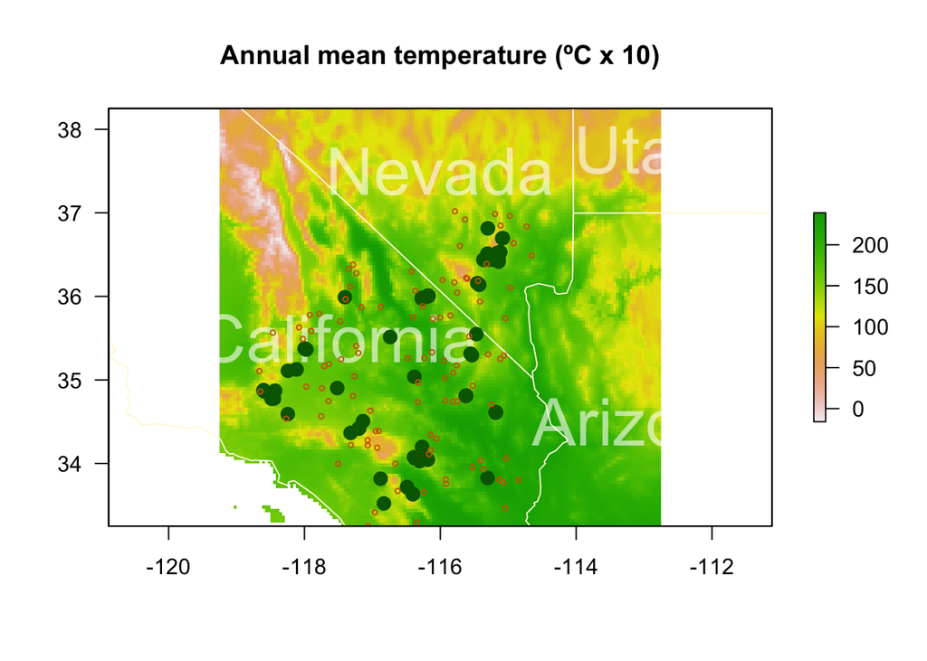

```r
require(raster)
# define circles with a radius of 50 km around the subsampled points
x = circles(subs[,c("lon","lat")], d=50000, lonlat=T)
# draw random points that must fall within the circles in object x
bg = spsample(x@polygons, 100, type='random', iter=100)
BClim = getData("worldclim", var="bio", res=2.5, path="data/")
YbrevRange = extent(-119.25,-112.75,33.25,38.25) # define the extent
BClim = crop(BClim, YbrevRange)
writeRaster(BClim, filename="./data/YbrevBC_2.5.grd", overwrite=T)
BClim = brick("data/YbrevBC_2.5.grd")
# this format plots 1 (of 19) variables stored in BClim
plot(BClim, 1, cex=0.5, legend=T, mar=par("mar"), xaxt="n", yaxt="n", main="Annual mean temperature (ºC x 10)")
map("state", xlim=c(-119, -110), ylim=c(33.5, 38), fill=F, col="cornsilk", add=T)
# state names
text(x=-117.5, y=35.5, "California", col=rgb(1,1,1,0.6), cex=3)
text(x=-116, y=37.5, "Nevada", col=rgb(1,1,1,0.6), cex=3)
text(x=-113, y=34.5, "Arizona", col=rgb(1,1,1,0.6), cex=3)
text(x=-113, y=37.75, "Utah", col=rgb(1,1,1,0.6), cex=3)
# plot the presence points
points(locs$lon, locs$lat, pch=20, cex=2, col="darkgreen")
# and the pseudo-absence points
points(bg, cex=0.5, col="darkorange3")
# add axes
axis(1,las=1)
axis(2,las=1)
box()
```

Now, the presence locations should be aligned with the corresponding enviromental variables of the location. This will create a data frame which relates the enviromental variables to the present or absent location. Intuitivly, this will create the a dataset which can be used to build classification model to predict the species localities for similar environmental conditions.

“bioclim”: Bioclimatic variables

Bioclimatic variables are derived from the monthly temperature and rainfall values in order to generate more biologically meaningful variables. These are often used in species distribution modeling and related ecological modeling techniques. The bioclimatic variables represent annual trends (e.g., mean annual temperature, annual precipitation) seasonality (e.g., annual range in temperature and precipitation) and extreme or limiting environmental factors (e.g., temperature of the coldest and warmest month, and precipitation of the wet and dry quarters). A quarter is a period of three months (1/4 of the year).

The raster package has the functionality to pull bioclim variables relevent to the location.

```r
# pulling bioclim values
Ybrev_bc = extract(BClim, subs[,c("lon","lat")]) # for the subsampled presence points
bg_bc = extract(BClim, bg) # for the pseudo-absence points
Ybrev_bc = data.frame(lon=subs$lon, lat=subs$lat, Ybrev_bc)
bgpoints = bg@coords
colnames(bgpoints) = c("lon","lat")
bg_bc = data.frame(cbind(bgpoints,bg_bc))
length(which(is.na(bg_bc$bio1))) # double-check for missing data
```

```
## [1] 0
```

```r
bg_bc = bg_bc[!is.na(bg_bc$bio1), ] # and pull out the missing lines
```

### Create dataframe from bioclim and presense/absance. The predictor variables are explained as below.

BIO1 = Annual Mean Temperature

BIO2 = Mean Diurnal Range (Mean of monthly (max temp - min temp))

BIO3 = Isothermality (BIO2/BIO7) (* 100)

BIO4 = Temperature Seasonality (standard deviation *100)

BIO5 = Max Temperature of Warmest Month

BIO6 = Min Temperature of Coldest Month

BIO7 = Temperature Annual Range (BIO5-BIO6)

BIO8 = Mean Temperature of Wettest Quarter

BIO9 = Mean Temperature of Driest Quarter

BIO10 = Mean Temperature of Warmest Quarter

BIO11 = Mean Temperature of Coldest Quarter

BIO12 = Annual Precipitation

BIO13 = Precipitation of Wettest Month

BIO14 = Precipitation of Driest Month

BIO15 = Precipitation Seasonality (Coefficient of Variation)

BIO16 = Precipitation of Wettest Quarter

BIO17 = Precipitation of Driest Quarter

BIO18 = Precipitation of Warmest Quarter

BIO19 = Precipitation of Coldest Quarter

```r
pres<-rep(1,dim(Ybrev_bc)[1])
temp1<-data.frame(pres,Ybrev_bc[,3:21])
pres<-rep(0,dim(bg_bc)[1])
temp2<-data.frame(pres,bg_bc[,3:21])
df<-rbind(temp1,temp2)
head(df,5)
```

```
##   pres bio1 bio2 bio3 bio4 bio5 bio6 bio7 bio8 bio9 bio10 bio11 bio12
## 1    1  131  123   40 6441  304    3  301   63  216   219    58   317
## 2    1  145  128   41 6560  320   11  309   77  232   234    69   314
## 3    1  156  134   42 6677  332   15  317   86  243   245    77   322
## 4    1  157  137   42 6735  336   12  324   88  245   246    77   303
## 5    1  157  140   42 6830  339    9  330   87  247   247    76   277
##   bio13 bio14 bio15 bio16 bio17 bio18 bio19
## 1    58     2    79   159     9    16   155
## 2    58     1    82   168     7    13   159
## 3    65     1    88   181     7    13   172
## 4    62     1    86   172     7    13   162
## 5    55     2    83   154     8     8   145
```

```r
tail(df,5)
```

```
##     pres bio1 bio2 bio3 bio4 bio5 bio6 bio7 bio8 bio9 bio10 bio11 bio12
## 143    0  206  140   40 7585  393   46  347  302  236   306   114   132
## 144    0  154  151   41 7652  357   -9  366   75  229   255    61   159
## 145    0  165  161   42 7491  368   -7  375   89  237   264    74   122
## 146    0  149  149   41 7620  352  -11  363   71  224   251    57   173
## 147    0  169  174   42 8295  384  -27  411   86  207   278    66   118
##     bio13 bio14 bio15 bio16 bio17 bio18 bio19
## 143    23     1    48    50     9    38    41
## 144    26     2    57    72    13    21    71
## 145    25     1    73    62     5     7    62
## 146    28     2    57    78    15    23    76
## 147    16     3    41    43    16    28    41
```

### Prior knowldege about the temperature range for Xantusia Riversiana

Tmax = 36 C Tmin = 6.6 C

Intuitively, if some latent structure generalise the environmental variables of a location. We can expect another location with similar laten structure presents favorable conditions for a species to distribute. This notion can be captured in a GRF.

```r
#covs <- df[1:1037, c("pres","bio1", "bio12")]# Not sure these are the best variables.
covs <- df

## 75% of the sample size
smp_size <- floor(0.75 * nrow(covs))
set.seed(123)
train_ind <- sample(seq_len(nrow(covs)), size = smp_size)
train <- covs[train_ind, ]
test <- covs[-train_ind, ]

pa_tr <- train$pres
pa_te <- test$pres
m1 <- graf(pa_tr, train[,2:20])
pred_df<-data.frame(predict(m1,test[,2:20]))

#print(paste("Area under ROC with No knowledge of thermal niche : ",auc(pa_te, pred_df$posterior.mode)))

thresh <- function(x) ifelse(x$bio1 < 150 | x$bio1 > 350 ,0.3, 0.6)

# fit the model, optimising the lengthscale
# fit a linear model
m.lin <- glm(pa_tr ~ bio1, data=train, family = binomial)
# wrap the predict method up in a new function
lin <- function(temp) predict(m.lin, temp, type = "response")
m3 <- graf(pa_tr, train[, c(2,6,7), drop = FALSE],opt.l = TRUE, prior = lin)
pred_df<-data.frame(predict(m3,test[, c(2,6,7), drop = FALSE]))
print(paste("Area under ROC with prior knowledge of thermal niche : ",auc(pa_te, pred_df$posterior.mode)))
```

```
## [1] "Area under ROC with prior knowledge of thermal niche :  0.742063492063492"
```

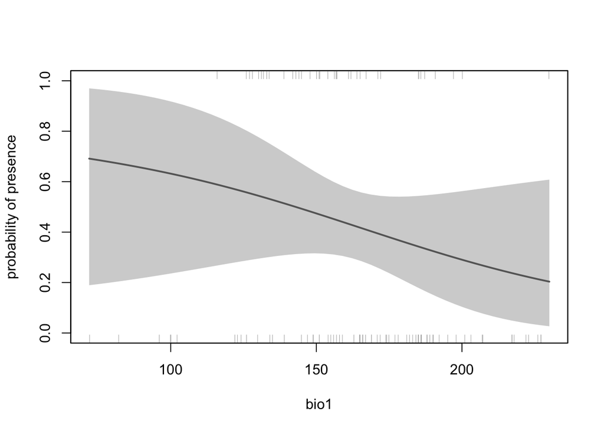

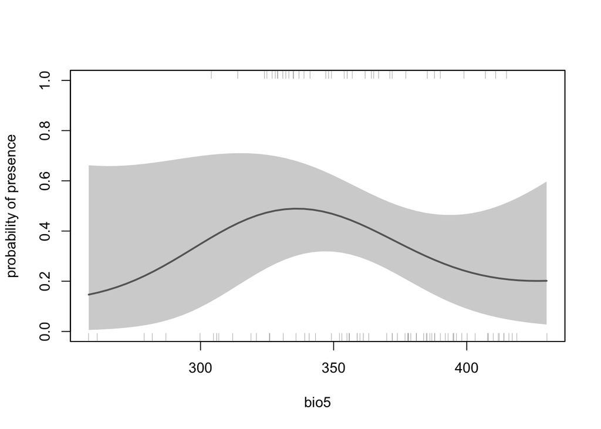

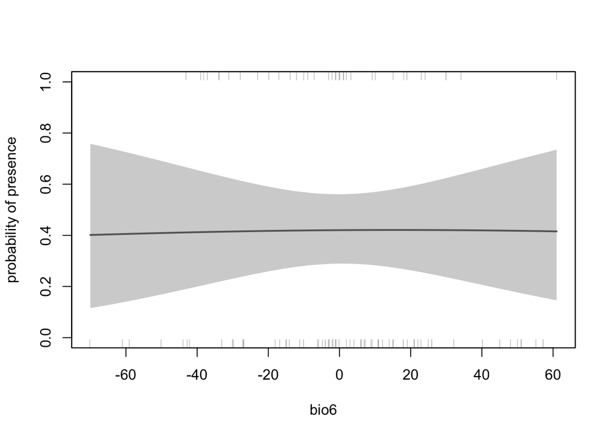

```r
plot(m3)
```

```r
library(ROCR)

prob <- pred_df$posterior.mode
pred <- prediction(prob, pa_te)
perf <- performance(pred, measure = "tpr", x.measure = "fpr")
auc <- performance(pred, measure = "auc")
auc <- auc@y.values[[1]]

roc.data <- data.frame(fpr=unlist(perf@x.values),
                       tpr=unlist(perf@y.values),
                       model="GP")
plot(roc.data$fpr,roc.data$tpr,type="l",col="red",ylab="TPR",xlab="FPR",main="ROC for GP vs MaxEnt",lwd=3.5)

group_p = kfold(Ybrev_bc, 5) # vector of group assignments splitting the Ybrev_bc into 5 groups
group_a = kfold(bg_bc, 5) # ditto for bg_bc

test = 3

train_p = Ybrev_bc[group_p!=test, c("lon","lat")]
train_a = bg_bc[group_a!=test, c("lon","lat")]
test_p = Ybrev_bc[group_p==test, c("lon","lat")]
test_a = bg_bc[group_a==test, c("lon","lat")]

me = maxent(BClim, p=train_p, a=train_a)
e = evaluate(test_p, test_a, me, BClim)

print(e)
```

```
## class          : ModelEvaluation
## n presences    : 9
## n absences     : 20
## AUC            : 0.5277778
## cor            : 0.003825402
## max TPR+TNR at : 0.5362951
```

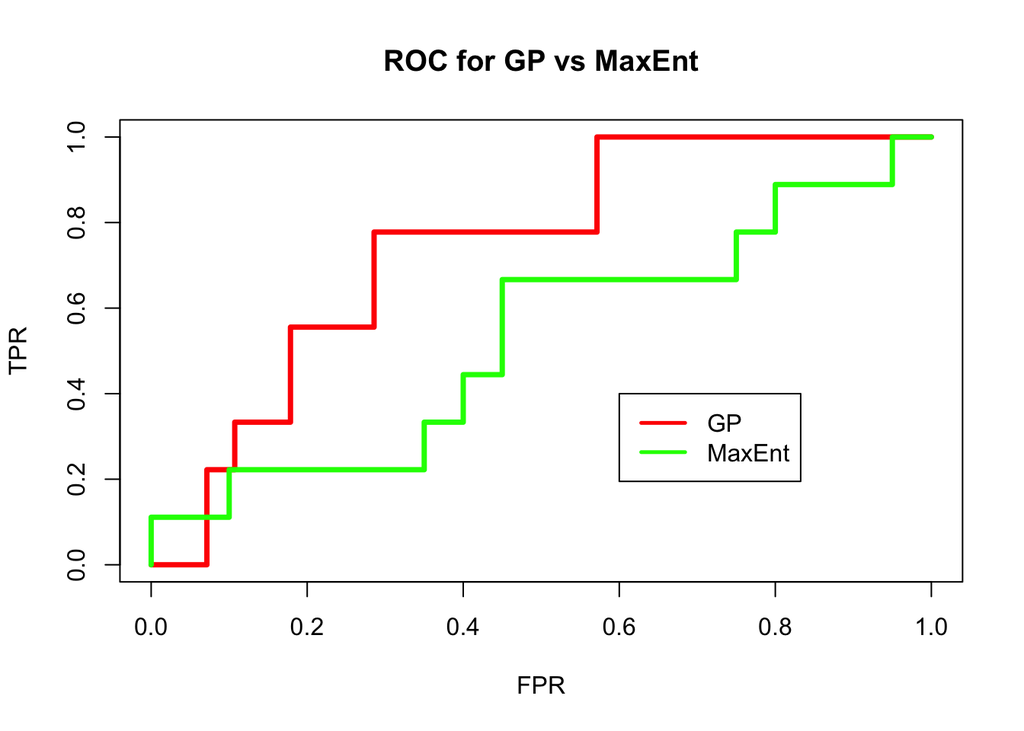

```r
probs_me<-c(e@presence,e@absence)
class_me<-c(rep(1,length(e@presence)),rep(0,length(e@absence)))
pred_me <- prediction(probs_me, class_me)
perf_me <- performance(pred_me, measure = "tpr", x.measure = "fpr")
auc_me <- performance(pred_me, measure = "auc")
auc_me <- auc_me@y.values[[1]]

roc.data_me <- data.frame(fpr=unlist(perf_me@x.values),
                       tpr=unlist(perf_me@y.values),
                       model="ME")

lines(roc.data_me$fpr,roc.data_me$tpr,type="l",col="green",lwd=3.5)

legend(0.6,0.4, # places a legend at the appropriate place
       c("GP","MaxEnt"), # puts text in the legend

lty=c(1,1), # gives the legend appropriate symbols (lines)

lwd=c(2.5,2.5),col=c("red","green"))
```

The prediction map for MaxEnt can be produced with the raster package. As a future work, the map interface should be developed to a the GP model.

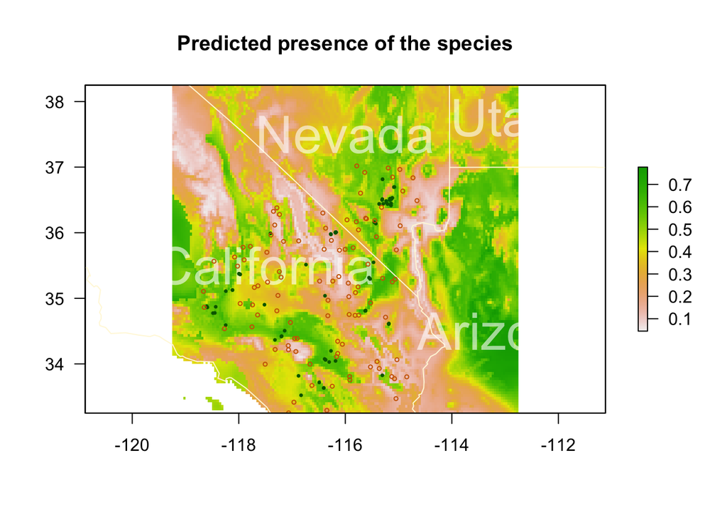

```r
pred_me = predict(me, BClim) # generate the predictions
# make a nice plot
plot(pred_me, 1, cex=0.5, legend=T, mar=par("mar"), xaxt="n", yaxt="n", main="Predicted presence of the species")
map("state", xlim=c(-119, -110), ylim=c(33.5, 38), fill=F, col="cornsilk", add=T)

# state names
text(x=-117.5, y=35.5, "California", col=rgb(1,1,1,0.6), cex=3)
text(x=-116, y=37.5, "Nevada", col=rgb(1,1,1,0.6), cex=3)
text(x=-113, y=34.5, "Arizona", col=rgb(1,1,1,0.6), cex=3)
text(x=-113, y=37.75, "Utah", col=rgb(1,1,1,0.6), cex=3)

# presence points
points(locs$lon, locs$lat, pch=20, cex=0.5, col="darkgreen")
# pseud-absence points
points(bg, cex=0.5, col="darkorange3")

# add axes
axis(1,las=1)
axis(2,las=1)

# restore the box around the map
box()
```